# Multiple Linear Regression - Predicting the Prices of house in Boston

INSOFE Lab

08th September 2018

- Objective - Build a multivariate linear regression model using lm()

**NOTE** Before starting this assignment please remember to clear your environment, you can do that by running the following code chunk

```r
rm(list = ls(all=TRUE))
```

# Agenda

- Get the data
- Explore the data
- Data Pre-processing
- Model the data
- Evaluation

# Reading & Understanding the Data

- Make sure the dataset is located in your current working directory

```r
housing_data <- read.csv("HousingData.csv")
sum(is.na(housing_data))
```

```
## [1] 0
```

- Use the str() function to get a feel for the dataset.

```r
str(housing_data)
```

```
## 'data.frame':    506 obs. of  13 variables:
##  $ CRIM   : num  0.00632 0.02731 0.02729 0.03237 0.06905 ...
##  $ ZN     : num  18 0 0 0 0 0 12.5 12.5 12.5 12.5 ...
##  $ INDUS  : num  2.31 7.07 7.07 2.18 2.18 2.18 7.87 7.87 7.87 7.87 ...
##  $ CHAS   : int  0 0 0 0 0 0 0 0 0 0 ...
##  $ NOX    : num  0.538 0.469 0.469 0.458 0.458 0.458 0.524 0.524 0.524 0.524 ...
##  $ RM     : num  6.58 6.42 7.18 7 7.15 ...
##  $ AGE    : num  65.2 78.9 61.1 45.8 54.2 58.7 66.6 96.1 100 85.9 ...
##  $ DIS    : num  4.09 4.97 4.97 6.06 6.06 ...
##  $ RAD    : int  1 2 2 3 3 3 5 5 5 5 ...
##  $ TAX    : int  296 242 242 222 222 222 311 311 311 311 ...
##  $ PTRATIO: num  15.3 17.8 17.8 18.7 18.7 18.7 15.2 15.2 15.2 15.2 ...
##  $ LSTAT  : num  4.98 9.14 4.03 2.94 5.33 ...
##  $ MEDV   : num  24 21.6 34.7 33.4 36.2 28.7 22.9 27.1 16.5 18.9 ...
```

```r
head(housing_data)
```

```
##      CRIM ZN INDUS CHAS   NOX    RM  AGE    DIS RAD TAX PTRATIO LSTAT MEDV
## 1 0.00632 18  2.31    0 0.538 6.575 65.2 4.0900   1 296    15.3  4.98 24.0
## 2 0.02731  0  7.07    0 0.469 6.421 78.9 4.9671   2 242    17.8  9.14 21.6
## 3 0.02729  0  7.07    0 0.469 7.185 61.1 4.9671   2 242    17.8  4.03 34.7
## 4 0.03237  0  2.18    0 0.458 6.998 45.8 6.0622   3 222    18.7  2.94 33.4
## 5 0.06905  0  2.18    0 0.458 7.147 54.2 6.0622   3 222    18.7  5.33 36.2
## 6 0.02985  0  2.18    0 0.458 6.430 58.7 6.0622   3 222    18.7  5.21 28.7
```

```r
tail(housing_data)
```

```
##        CRIM ZN INDUS CHAS   NOX    RM  AGE    DIS RAD TAX PTRATIO LSTAT
## 501 0.22438  0  9.69    0 0.585 6.027 79.7 2.4982   6 391    19.2 14.33
## 502 0.06263  0 11.93    0 0.573 6.593 69.1 2.4786   1 273    21.0  9.67
## 503 0.04527  0 11.93    0 0.573 6.120 76.7 2.2875   1 273    21.0  9.08
## 504 0.06076  0 11.93    0 0.573 6.976 91.0 2.1675   1 273    21.0  5.64
## 505 0.10959  0 11.93    0 0.573 6.794 89.3 2.3889   1 273    21.0  6.48
## 506 0.04741  0 11.93    0 0.573 6.030 80.8 2.5050   1 273    21.0  7.88
##     MEDV
## 501 16.8
## 502 22.4
## 503 20.6
## 504 23.9
## 505 22.0
## 506 11.9
```

- So, let’s get ready to predict the prices of houses!!

# Exploratory Analysis

## Summary Statistics

- Understand the distribution of various variables in the datset using the “summary()” function

```r
summary(housing_data)
```

```
##       CRIM                ZN             INDUS            CHAS
##  Min.   : 0.00632   Min.   :  0.00   Min.   : 0.46   Min.   :0.00000
##  1st Qu.: 0.08204   1st Qu.:  0.00   1st Qu.: 5.19   1st Qu.:0.00000
##  Median : 0.25651   Median :  0.00   Median : 9.69   Median :0.00000
##  Mean   : 3.61352   Mean   : 11.36   Mean   :11.14   Mean   :0.06917
##  3rd Qu.: 3.67708   3rd Qu.: 12.50   3rd Qu.:18.10   3rd Qu.:0.00000
##  Max.   :88.97620   Max.   :100.00   Max.   :27.74   Max.   :1.00000
##       NOX               RM             AGE              DIS
##  Min.   :0.3850   Min.   :3.561   Min.   :  2.90   Min.   : 1.130
##  1st Qu.:0.4490   1st Qu.:5.886   1st Qu.: 45.02   1st Qu.: 2.100
##  Median :0.5380   Median :6.208   Median : 77.50   Median : 3.207
##  Mean   :0.5547   Mean   :6.285   Mean   : 68.57   Mean   : 3.795
##  3rd Qu.:0.6240   3rd Qu.:6.623   3rd Qu.: 94.08   3rd Qu.: 5.188
##  Max.   :0.8710   Max.   :8.780   Max.   :100.00   Max.   :12.127
##       RAD              TAX           PTRATIO          LSTAT
##  Min.   : 1.000   Min.   :187.0   Min.   :12.60   Min.   : 1.73
##  1st Qu.: 4.000   1st Qu.:279.0   1st Qu.:17.40   1st Qu.: 6.95
##  Median : 5.000   Median :330.0   Median :19.05   Median :11.36
##  Mean   : 9.549   Mean   :408.2   Mean   :18.46   Mean   :12.65
##  3rd Qu.:24.000   3rd Qu.:666.0   3rd Qu.:20.20   3rd Qu.:16.95
##  Max.   :24.000   Max.   :711.0   Max.   :22.00   Max.   :37.97
##       MEDV
##  Min.   : 5.00
##  1st Qu.:17.02
##  Median :21.20
##  Mean   :22.53
##  3rd Qu.:25.00
##  Max.   :50.00
```

## Scatter Plots

- A few bi-variate relationships are plotted below, but you are encouraged to explore the dataset in more detail

Try this out * pairs(~CRIM+ZN+INDUS+NOX+RM+LSTAT,data=boston_housing_data,main=“Scatterplot matrix with selected attributes”)

[figure not shown]

```r
par(mfrow = c(2,2))

plot(housing_data$LSTAT, housing_data$MV, ylab = "Median House Price", xlab = "Percentage of people in the lower economic strata", main = "Housing Price vs Status")

plot(housing_data$CRIM, housing_data$MV, ylab = "Median House Price", xlab = "Per capita crime by town", main = "Housing Price vs Per Capita Crime")

plot(housing_data$NOX, housing_data$MV, ylab = "Median House Price", xlab = "Nitric Oxide Concentration in ppm", main = "Housing Price vs NOX concentration in ppm")

plot(housing_data$INDUS, housing_data$MV, ylab = "Median House Price", xlab = "Proportion of non-retail business acres per town", main = "Housing Price vs Non-retail business area")
```

- Report your observation looking at above plots

## Correlation Plot

- Let’s have a look at the various correlations between the variables in the dataset

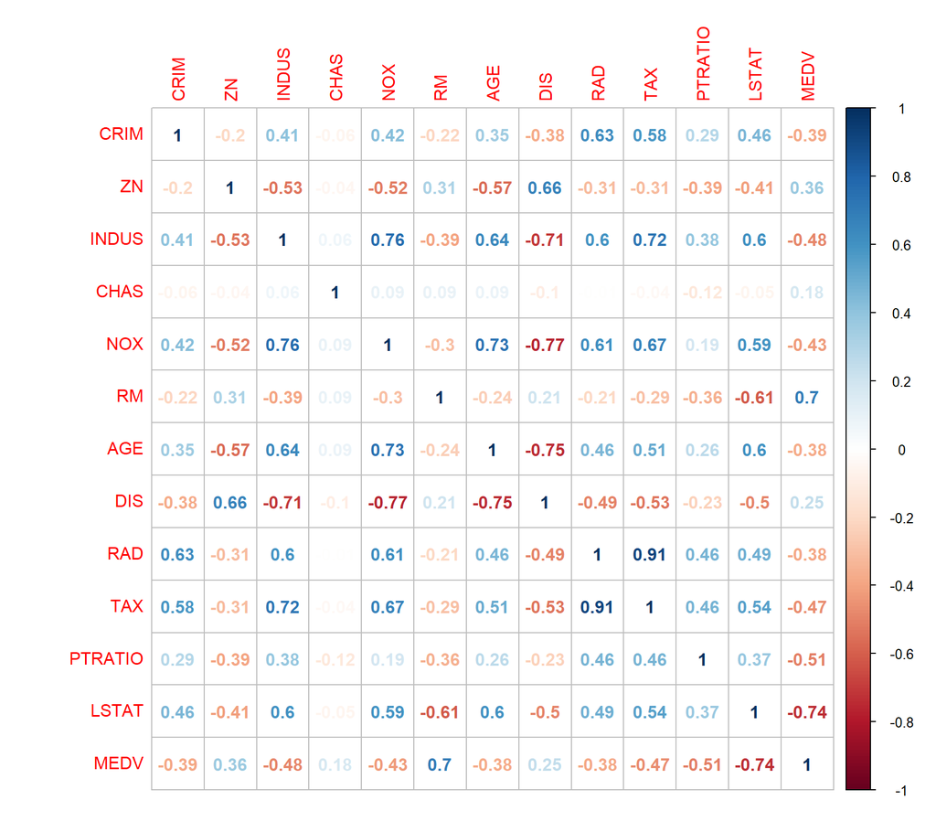

```r
library(corrplot)
correlation_XPairwise = cor(housing_data)
corrplot(cor(housing_data, use = "complete.obs"), method = "number") # If use is "complete.obs" then missing values are handled by casewise deletion
```

```r
# Write the pairwise correlation matrix to a csv file for later analysis
write.table(correlation_XPairwise,file="pairwiseCorrelations1.csv",row.names=FALSE,col.names=FALSE,sep=",")
```

- Observe the variables which are highly correlated (RAD and TAX)

# Data Pre-processing

- Today we will impute missing values and standardize the data **after** splitting the data into train and test sets

## Train/Test Split

- 70/30 - Train/Test split

```r
set.seed(123)

# the "sample()" function helps us to randomly sample 70% of the row indices of the dataset


train_rows <- sample(x = 1:nrow(housing_data), size = 0.7*nrow(housing_data))

# We use the above indices to subset the train and test sets from the data

train_data <- housing_data[train_rows, ]

test_data <- housing_data[-train_rows, ]

dim(train_data)
```

```
## [1] 354  13
```

```r
dim(test_data)
```

```
## [1] 152  13
```

## Missing Values Imputation

- Find out the number of missing values in the dataset
- Impute the missing values using the “preProcess()” function in conjunction with the “medianImpute” method

```r
library(caret)
sum(is.na(train_data))
```

```
## [1] 0
```

```r
imputer_values <- preProcess(x = train_data, method = "medianImpute")
class(imputer_values)
```

```
## [1] "preProcess"
```

```r
train_data <- predict(object = imputer_values, newdata = train_data)

sum(is.na(train_data))
```

```
## [1] 0
```

```r
sum(is.na(test_data))
```

```
## [1] 0
```

```r
test_data <- predict(object = imputer_values, newdata = test_data)

sum(is.na(test_data))
```

```
## [1] 0
```

## Standardizing the Data

- We will use the Caret pakcage to standardize the data after the split using the **“preProcess()”** function
- It saves the metrics such as mean and standard deviation used for calculating the standardized value by creating a model object
- We can then use the model object in the **“predict()”** function to standardize any other unseen dataset with the same distribuiton and variables

```r
library(caret)

# The "preProcess()" function creates a model object required for standardizing unseen data

# Do not standardize the target variable

std_model <- preProcess(train_data[, !names(train_data) %in% c("MV")], method = c("center","scale"))
std_model
```

```
## Created from 354 samples and 13 variables
##
## Pre-processing:
##   - centered (13)
##   - ignored (0)
##   - scaled (13)
```

```r
# The predict() function is used to standardize any other unseen data

train_data[, !names(train_data) %in% c("MV")] <- predict(object = std_model, newdata = train_data[, !names(train_data) %in% c("MV")])

test_data[, !names(train_data) %in% c("MV")] <- predict(object = std_model, newdata = test_data[, !names(train_data) %in% c("MV")])
```

# Modelling the Data

## Basic Model

- The “.” adds all the variables other than the response variable while building the model.

```r
# Capturing the Start and end time taken for model building
start_time = Sys.time()
model_basic <- lm(formula = MEDV~. , data = train_data)
end_time = Sys.time()
time_taken = end_time - start_time
time_taken
```

```
## Time difference of 0.015625 secs
```

```r
cat(end_time - start_time)
```

```
## 0.015625
```

## Model Summary

```r
summary(model_basic)
```

```
##
## Call:
## lm(formula = MEDV ~ ., data = train_data)
##
## Residuals:
##     Min      1Q  Median      3Q     Max
## -1.7708 -0.3147 -0.0534  0.1818  2.6261
##
## Coefficients:
##               Estimate Std. Error t value Pr(>|t|)
## (Intercept) -1.583e-16  2.851e-02   0.000 1.000000
## CRIM        -1.018e-01  3.779e-02  -2.695 0.007385 **
## ZN           1.149e-01  4.176e-02   2.751 0.006263 **
## INDUS        3.864e-02  5.596e-02   0.691 0.490323
## CHAS         9.507e-02  2.971e-02   3.200 0.001503 **
## NOX         -2.295e-01  5.990e-02  -3.831 0.000152 ***
## RM           2.576e-01  3.932e-02   6.552 2.09e-10 ***
## AGE          1.327e-02  5.095e-02   0.260 0.794684
## DIS         -3.474e-01  5.728e-02  -6.066 3.49e-09 ***
## RAD          3.119e-01  7.672e-02   4.065 5.96e-05 ***
## TAX         -2.598e-01  8.402e-02  -3.092 0.002154 **
## PTRATIO     -2.159e-01  3.816e-02  -5.658 3.24e-08 ***
## LSTAT       -4.780e-01  4.834e-02  -9.888  < 2e-16 ***
## ---
## Signif. codes:  0 '***' 0.001 '**' 0.01 '*' 0.05 '.' 0.1 ' ' 1
##
## Residual standard error: 0.5364 on 341 degrees of freedom
## Multiple R-squared:  0.7221, Adjusted R-squared:  0.7123
## F-statistic: 73.83 on 12 and 341 DF,  p-value: < 2.2e-16
```

- Question: How good is the model?
- A basic assessment of the model can be obtained by reading off the R^2 (and adjusted R^2) values.
- Caution : A good R^2 value alone can be misleading.
- Question: Is the model significant?
- Important : Both model significance as well as significance of the individual coefficients need to be considered.

## Residual Plots

- Interpreting the diagnostic plots to check for the linear regression assumptions

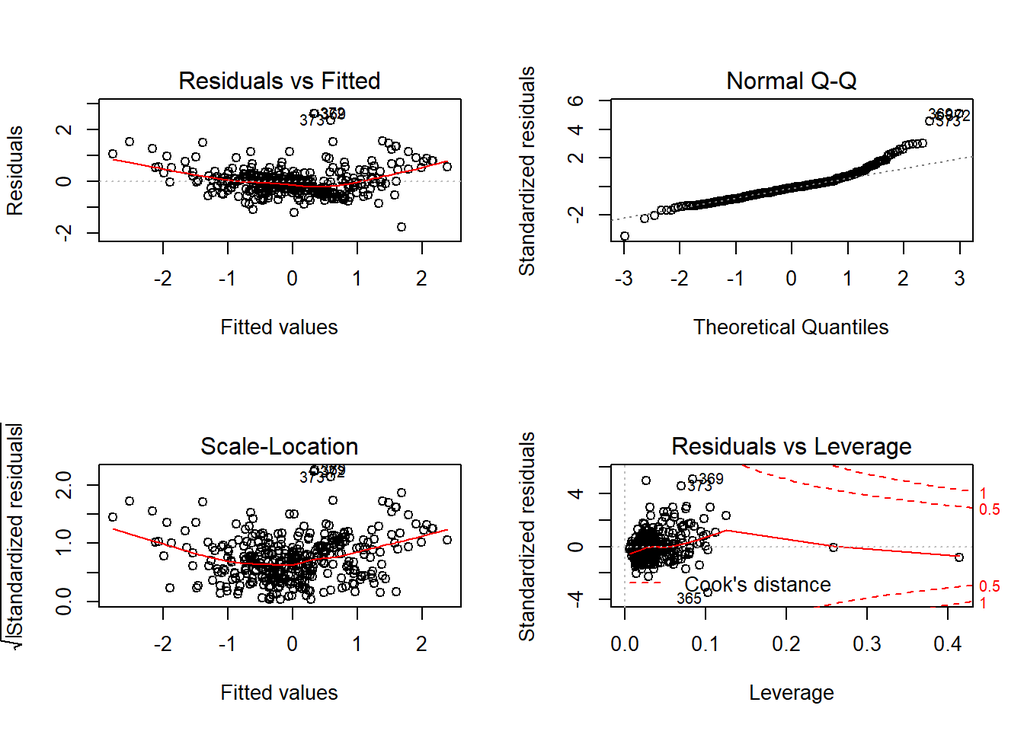

```r
par(mfrow = c(2,2))

plot(model_basic)
```

# Influential Observations

## Leverage

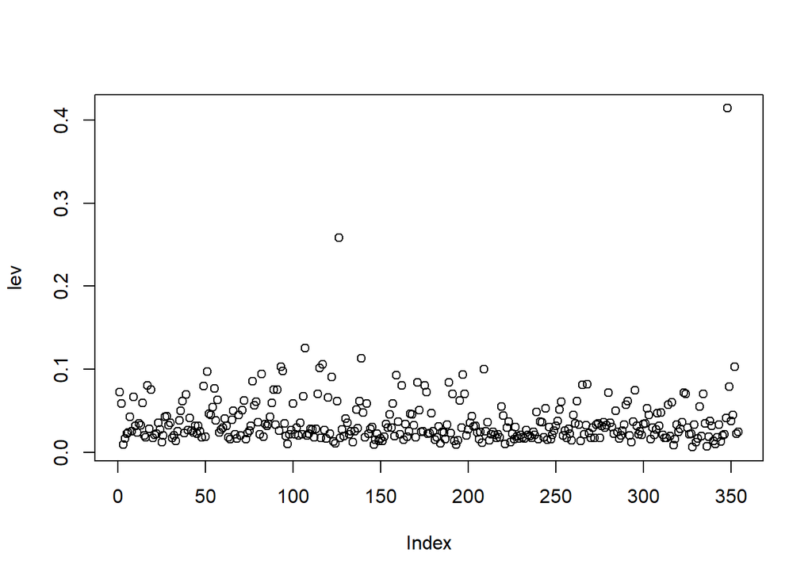

```r
lev= hat(model.matrix(model_basic))
plot(lev)
```

- Suppose we would like to remove records with leverage values greater than 0.3

```r
train_data[lev>0.3,]
```

```
##         CRIM         ZN     INDUS       CHAS       NOX        RM       AGE
## 381 9.993585 -0.4659467 0.9707164 -0.2570562 0.9886801 0.9650068 0.8350835
##           DIS      RAD      TAX   PTRATIO     LSTAT      MEDV
## 381 -1.151141 1.650549 1.510917 0.8174269 0.6731893 -1.339813
```

```r
train_data_lev<-train_data[-(lev>0.3),]
dim(train_data_lev)
```

```
## [1] 353  13
```

```r
## Method: Convention - If there are n data points and p parameters, then threshold can be taken a 3*p/n
# lev_threshold <- 3*length(model1$coefficients)/length(lev)
# train[lev>lev_threshold,]
# length(train[lev>lev_threshold,])
```

# Cook’s distance

- Identifying influential observations and handling them

```r
# Identify records with high Cook's distance

cook = cooks.distance(model_basic)
plot(cook,ylab="Cook's distances")
max=as.numeric(which.max(cook))
max
```

```
## [1] 189
```

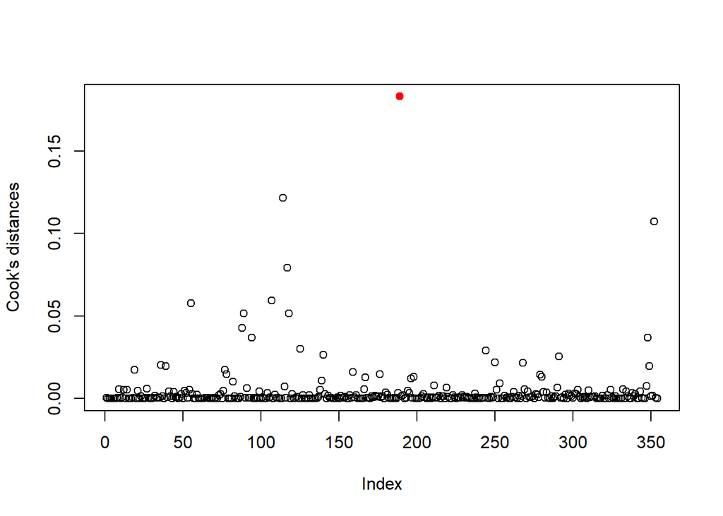

```r
points(max,cook[max],col='red', pch=19)
```

```r
train_cook<-train_data_lev[-max,]
dim(train_cook)
```

```
## [1] 352  13
```

- Model building after removing influential observations

```r
model_basic2 <- lm(formula = MEDV~. , data = train_cook)
summary(model_basic2)
```

```
##
## Call:
## lm(formula = MEDV ~ ., data = train_cook)
##
## Residuals:
##      Min       1Q   Median       3Q      Max
## -1.76416 -0.31092 -0.05249  0.18222  2.62543
##
## Coefficients:
##              Estimate Std. Error t value Pr(>|t|)
## (Intercept)  0.001012   0.028639   0.035 0.971824
## CRIM        -0.101255   0.037866  -2.674 0.007858 **
## ZN           0.115928   0.041839   2.771 0.005900 **
## INDUS        0.038014   0.056058   0.678 0.498156
## CHAS         0.095314   0.029778   3.201 0.001500 **
## NOX         -0.233713   0.060797  -3.844 0.000144 ***
## RM           0.256290   0.039527   6.484 3.16e-10 ***
## AGE          0.014720   0.051165   0.288 0.773759
## DIS         -0.346303   0.057429  -6.030 4.28e-09 ***
## RAD          0.310339   0.077021   4.029 6.91e-05 ***
## TAX         -0.255483   0.084286  -3.031 0.002624 **
## PTRATIO     -0.217568   0.038340  -5.675 2.98e-08 ***
## LSTAT       -0.478738   0.048835  -9.803  < 2e-16 ***
## ---
## Signif. codes:  0 '***' 0.001 '**' 0.01 '*' 0.05 '.' 0.1 ' ' 1
##
## Residual standard error: 0.5372 on 339 degrees of freedom
## Multiple R-squared:  0.7221, Adjusted R-squared:  0.7122
## F-statistic:  73.4 on 12 and 339 DF,  p-value: < 2.2e-16
```

- Observation: Adjusted R^2 did not change much

# stepAIC model

- “stepAIC()” is a function in the MASS package
- stepAIC uses AIC (Akaike information criterion) to either drop variables (“backward” direction) or add variables (“forward” direction) from the model

```r
library(MASS)

model_aic <- stepAIC(model_basic2, direction = "both")
```

```
## Start:  AIC=-424.65
## MEDV ~ CRIM + ZN + INDUS + CHAS + NOX + RM + AGE + DIS + RAD +
##     TAX + PTRATIO + LSTAT
##
##           Df Sum of Sq     RSS     AIC
## - AGE      1    0.0239  97.868 -426.57
## - INDUS    1    0.1327  97.976 -426.17
## <none>                  97.844 -424.65
## - CRIM     1    2.0638  99.907 -419.30
## - ZN       1    2.2159 100.060 -418.77
## - TAX      1    2.6518 100.496 -417.24
## - CHAS     1    2.9571 100.801 -416.17
## - NOX      1    4.2652 102.109 -411.63
## - RAD      1    4.6859 102.530 -410.18
## - PTRATIO  1    9.2943 107.138 -394.71
## - DIS      1   10.4948 108.339 -390.79
## - RM       1   12.1339 109.978 -385.50
## - LSTAT    1   27.7370 125.581 -338.80
##
## Step:  AIC=-426.57
## MEDV ~ CRIM + ZN + INDUS + CHAS + NOX + RM + DIS + RAD + TAX +
##     PTRATIO + LSTAT
##
##           Df Sum of Sq     RSS     AIC
## - INDUS    1    0.1301  97.998 -428.10
## <none>                  97.868 -426.57
## + AGE      1    0.0239  97.844 -424.65
## - CRIM     1    2.0739  99.941 -421.18
## - ZN       1    2.1920 100.060 -420.77
## - TAX      1    2.6299 100.497 -419.23
## - CHAS     1    2.9708 100.838 -418.04
## - NOX      1    4.3861 102.254 -413.13
## - RAD      1    4.6682 102.536 -412.16
## - PTRATIO  1    9.2763 107.144 -396.69
## - DIS      1   12.5277 110.395 -386.17
## - RM       1   13.0489 110.917 -384.51
## - LSTAT    1   30.1324 128.000 -334.08
##
## Step:  AIC=-428.1
## MEDV ~ CRIM + ZN + CHAS + NOX + RM + DIS + RAD + TAX + PTRATIO +
##     LSTAT
##
##           Df Sum of Sq     RSS     AIC
## <none>                  97.998 -428.10
## + INDUS    1    0.1301  97.868 -426.57
## + AGE      1    0.0212  97.976 -426.17
## - ZN       1    2.0970 100.095 -422.64
## - CRIM     1    2.1217 100.119 -422.56
## - TAX      1    2.6916 100.689 -420.56
## - CHAS     1    3.1025 101.100 -419.13
## - NOX      1    4.2849 102.283 -415.03
## - RAD      1    4.6449 102.643 -413.80
## - PTRATIO  1    9.1463 107.144 -398.69
## - RM       1   12.9264 110.924 -386.48
## - DIS      1   13.7923 111.790 -383.75
## - LSTAT    1   30.0549 128.053 -335.94
```

```r
summary(model_aic)
```

```
##
## Call:
## lm(formula = MEDV ~ CRIM + ZN + CHAS + NOX + RM + DIS + RAD +
##     TAX + PTRATIO + LSTAT, data = train_cook)
##
## Residuals:
##     Min      1Q  Median      3Q     Max
## -1.7711 -0.3088 -0.0552  0.1902  2.6395
##
## Coefficients:
##              Estimate Std. Error t value Pr(>|t|)
## (Intercept)  0.001063   0.028577   0.037 0.970360
## CRIM        -0.102552   0.037743  -2.717 0.006921 **
## ZN           0.111396   0.041238   2.701 0.007252 **
## CHAS         0.097238   0.029595   3.286 0.001123 **
## NOX         -0.219388   0.056817  -3.861 0.000135 ***
## RM           0.256906   0.038306   6.707 8.28e-11 ***
## DIS         -0.360343   0.052015  -6.928 2.14e-11 ***
## RAD          0.291983   0.072627   4.020 7.16e-05 ***
## TAX         -0.227754   0.074420  -3.060 0.002386 **
## PTRATIO     -0.213707   0.037882  -5.641 3.55e-08 ***
## LSTAT       -0.471038   0.046061 -10.226  < 2e-16 ***
## ---
## Signif. codes:  0 '***' 0.001 '**' 0.01 '*' 0.05 '.' 0.1 ' ' 1
##
## Residual standard error: 0.5361 on 341 degrees of freedom
## Multiple R-squared:  0.7216, Adjusted R-squared:  0.7135
## F-statistic:  88.4 on 10 and 341 DF,  p-value: < 2.2e-16
```

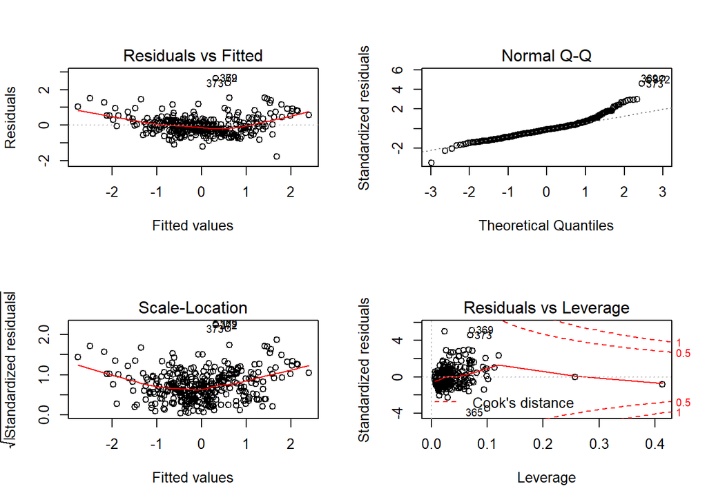

```r
par(mfrow = c(2,2))

plot(model_aic)
```

## Modifying the Model with the VIF

**Variance Inflation Factor :** ** Checking for multicollinearity through VIF.

$$VIF_{k} = \dfrac{1}{1 - R_{k}^2}$$

$R_{k}^2$ is the R^2-value obtained by regressing the kth predictor on the remaining predictors. VIF gives us an idea of multi-collinearity

- Every explanatory variable would have a VIF score
- A VIF > 4 means that there are signs of multi-collinearity and anything greater than 10 means that an explanatory variable should be dropped
- We use the “vif()” function from the car package.

```r
library(car)

vif(model_basic)
```

```
##     CRIM       ZN    INDUS     CHAS      NOX       RM      AGE      DIS
## 1.752315 2.139429 3.842197 1.082961 4.402127 1.896820 3.185474 4.025724
##      RAD      TAX  PTRATIO    LSTAT
## 7.221158 8.662398 1.786758 2.867703
```

```r
vif(model_aic)
```

```
##     CRIM       ZN     CHAS      NOX       RM      DIS      RAD      TAX
## 1.748825 2.064547 1.075409 3.857699 1.801867 3.279677 6.455871 6.794752
##  PTRATIO    LSTAT
## 1.737208 2.568313
```

- After applying the stepAIC, the VIF values have slightly reduced, but the variables “RAD” and “TAX” have VIF values higher than 4
- Let’s take a look at the correlation between the “RAD” and “TAX” variables

```r
cor(housing_data$RAD, housing_data$TAX,use='complete.obs')
```

```
## [1] 0.9102282
```

```r
names(train_data)
```

```
##  [1] "CRIM"    "ZN"      "INDUS"   "CHAS"    "NOX"     "RM"      "AGE"
##  [8] "DIS"     "RAD"     "TAX"     "PTRATIO" "LSTAT"   "MEDV"
```

```r
model3 <- lm(formula = MEDV ~ CRIM + ZN + CHAS + NOX + RM + DIS + RAD + PTRATIO + TAX + LSTAT, data = train_data)
summary(model3)
```

```
##
## Call:
## lm(formula = MEDV ~ CRIM + ZN + CHAS + NOX + RM + DIS + RAD +
##     PTRATIO + TAX + LSTAT, data = train_data)
##
## Residuals:
##      Min       1Q   Median       3Q      Max
## -1.77687 -0.30863 -0.05633  0.19398  2.64025
##
## Coefficients:
##               Estimate Std. Error t value Pr(>|t|)
## (Intercept) -1.435e-16  2.845e-02   0.000 1.000000
## CRIM        -1.031e-01  3.767e-02  -2.738 0.006511 **
## ZN           1.104e-01  4.116e-02   2.682 0.007671 **
## CHAS         9.704e-02  2.952e-02   3.287 0.001118 **
## NOX         -2.156e-01  5.606e-02  -3.846 0.000143 ***
## RM           2.579e-01  3.814e-02   6.761 5.92e-11 ***
## DIS         -3.611e-01  5.179e-02  -6.973 1.61e-11 ***
## RAD          2.936e-01  7.237e-02   4.056 6.18e-05 ***
## PTRATIO     -2.120e-01  3.769e-02  -5.626 3.84e-08 ***
## TAX         -2.318e-01  7.418e-02  -3.124 0.001936 **
## LSTAT       -4.708e-01  4.569e-02 -10.306  < 2e-16 ***
## ---
## Signif. codes:  0 '***' 0.001 '**' 0.01 '*' 0.05 '.' 0.1 ' ' 1
##
## Residual standard error: 0.5352 on 343 degrees of freedom
## Multiple R-squared:  0.7216, Adjusted R-squared:  0.7135
## F-statistic: 88.93 on 10 and 343 DF,  p-value: < 2.2e-16
```

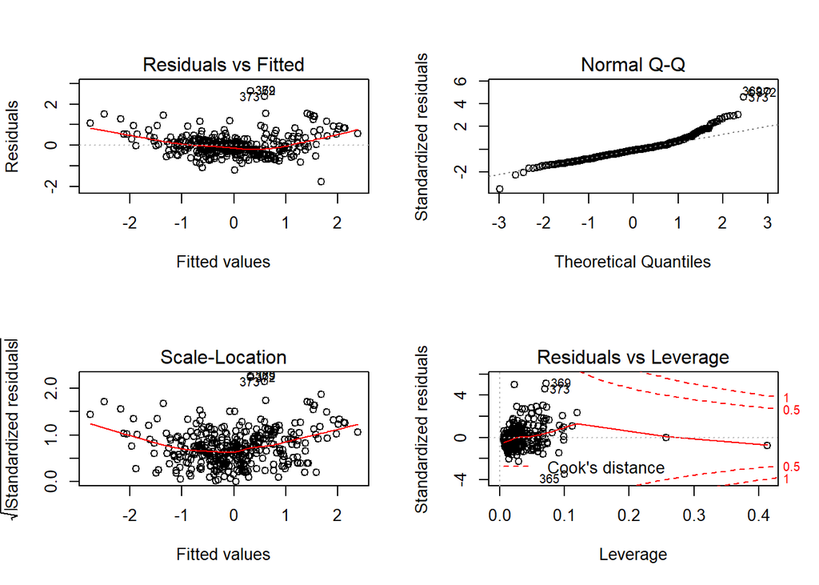

```r
par(mfrow = c(2,2))

plot(model3)
```

```r
vif(model3)
```

```
##     CRIM       ZN     CHAS      NOX       RM      DIS      RAD  PTRATIO
## 1.748581 2.087353 1.074085 3.872451 1.792957 3.305305 6.454102 1.750195
##      TAX    LSTAT
## 6.781146 2.571896
```

# Evaluation and Selection of Model

## Picking the Right Model

# Communication

## Prediction

Predict the Housing prices of the unseen boston housing data, using the chosen model.

```r
preds_model <- predict(model3, test_data[, !(names(test_data) %in% c("MEDV"))])
preds_model
```

```
##            3            6            8            9           10
##  0.824390125  0.271374108 -0.506319720 -1.443429683 -0.546164844
##           18           26           27           29           30
## -0.655031177 -0.953318293 -0.803117276 -0.386455643 -0.231592001
##           33           34           36           38           42
## -1.498941571 -0.922246139  0.151583301  0.078204114  0.559914068
##           49           53           63           70           72
## -1.690710757  0.487578260  0.083574085 -0.242890135 -0.112003061
##           83           92           93           96           99
##  0.351279420  0.534393468  0.657546202  0.696288096  1.326933291
##          100          105          106          111          113
##  1.008576681 -0.121506593 -0.453040882 -0.220916998 -0.237081816
##          114          116          126          130          131
## -0.268935053 -0.222246485 -0.045144514 -0.970094322 -0.313747905
##          133          136          141          144          147
## -0.286467787 -0.649928326 -1.094085747 -1.250830976 -0.536921211
##          152          153          156          186          189
## -0.397030060 -0.056301506  0.101102354  0.220460040  1.060052335
##          196          197          199          200          203
##  1.878237634  1.334242614  1.159957454  0.706806009  1.463077677
##          208          210          211          213          216
## -0.598364506 -0.603783148  0.006584419  0.075459461  0.192454509
##          218          219          220          221          229
##  0.574520059  0.276993663  0.836232777  1.223926606  1.383264582
##          232          238          239          240          242
##  1.141137514  1.063722494  0.591923092  0.568714991  0.024399263
##          246          248          253          255          256
## -1.147287424 -0.389939484  0.158322480  0.036580849 -0.224708059
##          257          258          259          260          268
##  1.529802452  2.166283227  1.483339574  1.347370630  1.888974328
##          270          271          276          277          278
##  0.412532579 -0.063796866  1.210913275  1.459065004  1.415479129
##          279          281          288          290          292
##  0.820855709  1.684803516  0.401086924  0.369123250  1.240573301
##          295          296          300          308          314
##  0.122474573  0.552066563  0.912587185  1.088516981  0.330346919
##          315          323          324          327          330
##  0.282016645  0.032073624 -0.355287863  0.105922344  0.170829252
##          332          333          336          338          346
## -0.367894401  0.055038677 -0.230485890 -0.383737885 -0.744495946
##          347          351          352          354          355
## -0.929033098 -0.326049975 -0.345286620  0.132083141 -0.981896149
##          356          362          364          370          376
## -0.720022595 -0.382461325 -0.103746323  1.280312565  0.218201751
##          379          380          382          386          389
## -0.859390853 -0.717776831 -0.556853975 -1.705895306 -1.834042772
##          391          394          396          400          403
## -0.608029941 -0.290509406 -0.311002958 -1.362791351 -0.542739151
##          405          406          410          411          412
## -1.704691361 -1.642059469 -0.195280203 -0.371349785 -0.367351198
##          413          417          421          422          424
## -2.028719405 -0.796212316 -0.291690969 -0.434761950 -0.739773170
##          427          431          436          437          439
## -0.328598310 -0.242127565 -0.855940046 -0.583960949 -1.795615183
##          447          450          451          455          457
## -0.523710250 -0.583221020 -0.355867429 -0.513323452 -0.757354862
##          471          474          476          483          486
## -0.337312311  0.284611952 -0.742364210  0.604701003 -0.076311094
##          490          495          496          497          499
## -1.614367987 -0.216833517 -0.650360603 -0.987640709 -0.143544722
##          501          505
## -0.250953246  0.405998711
```

## Performance Metrics

Once we choose the model we have to report performance metrics on the test data. We are going to report four error metrics for regression.

### Error Metrics for Regression

- Mean Absolute Error (MAE):

$$MAE = \dfrac{1}{n}\times\sum_{i = 1}^{n}|y_{i} - \hat{y_{i}}|$$

- Mean Squared Error (MSE):

$$MSE = \dfrac{1}{n}\times\sum_{i = 1}^{n}(y_{i} - \hat{y_{i}})^2$$

- Root Mean Squared Error (RMSE):

$$RMSE = \sqrt{\dfrac{1}{n}\times\sum_{i = 1}^{n}(y_{i} - \hat{y_{i}})^2}$$

- Mean Absolute Percentage Error (MAPE):

$$MAPE = \dfrac{100}{n}\times\dfrac{\sum_{i = 1}^{n}\mid{y_{i} - \hat{y_{i}}}\mid}{y_{i}}$$

### Report Performance Metrics

- Report performance metrics obtained by using the chosen model on the test data

## Test Data

### Evaluating the Model

```r
library(DMwR)
# Error verification on train data

regr.eval(train_data$MEDV, model3$fitted.values)
```

```
##       mae       mse      rmse      mape
## 0.3681756 0.2775650 0.5268443 2.7076815
```

```r
# Error verification on test data

regr.eval(test_data$MEDV, preds_model)
```

```
##       mae       mse      rmse      mape
## 0.3872722 0.2461802 0.4961655 1.8771821
```

- Observation: Error Metrics is not far apart for train and test data after its evaluated on the third model
- Future Scope:
- 1. More models can be tried to improve Adjusted R^2
- 2. Data Transformation can be applied